## Assignment 4

#### Due Thursday, October 3

The purpose of this assignment is to give you practice using lubridate commands and to review dplyr, ggplot2, and basic exploratory data analysis skills.

Turn in an HTML file and this R Markdown file after you have edited it.

### Data

The questions involve three data sets involving international flights arriving to Chicago’s O’Hare airport in the years 2016, 2017, and 2018.

Each data set is in a separate CSV file: `ORD-2016.csv`, `ORD-2017.csv`, and `ORD-2018.csv`.

### 1

> Read in the three data sets. Use `bind_rows()` to combine these data sets into a single data set. Change the date variable into standard date format. Add columns for year, month (character valued, Jan-Dec), and day of the week (character valued, Sun - Sat).

Rename and reorder variables in the data set, but keep all variables.

> After these changes, how many rows and columns are in the data set?

```r
ord = bind_rows(ord2016,ord2017,ord2018) %>%
  mutate(date = mdy(date))%>%
  mutate(year=year(date),
         month=month(date, label = TRUE),
         wday=wday(date, label=TRUE)) %>%
   rename(passengers = all_total,
         flights = all_flights)
```

### 2

> Calculate the total numbers of flights and passengers in each year and store this information in a table. Which year has the most of each?

```r
ord %>%
  group_by(year)%>%
  summarise(passengers = sum(passengers),
            flights = sum(flights))
```

```
## # A tibble: 3 x 3
##    year passengers flights
##   <dbl>      <dbl>   <dbl>
## 1  2016    4873212   26519
## 2  2017    5189091   28040
## 3  2018    5601907   29529
```

### 3

> Make a table that displays the total number of passengers by month of the year and year. Display these values with a bar chart where month is the primary variable on the x-axis and there is a separate bar (not stacked, and in a different color) for each year. Add meaningful labels and a title to this graph. Describe any patterns or interesting trends that you see.

```r
ord %>%
  group_by(year,month)%>%
  summarise(passengers=sum(passengers))
```

```
## # A tibble: 36 x 3
## # Groups:   year [3]
##     year month passengers
##    <dbl> <ord>      <dbl>
##  1  2016 Jan       382618
##  2  2016 Feb       297269
##  3  2016 Mar       371282
##  4  2016 Apr       397915
##  5  2016 May       419454
##  6  2016 Jun       471971
##  7  2016 Jul       535122
##  8  2016 Aug       509441
##  9  2016 Sep       416257
## 10  2016 Oct       387634
## # ... with 26 more rows
```

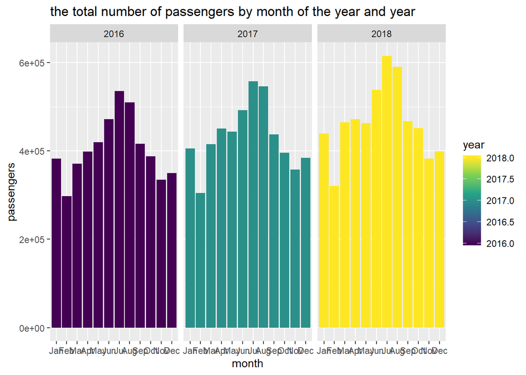

```r
ord %>%
  ggplot(aes(x=month,y=passengers, fill=year),position="dodge")+
  geom_col()+
  facet_wrap(~year)+
  ggtitle("the total number of passengers by month of the year and year")
```

```r
# ord %>%
#     mutate(year=as.character(year))%>%
#     ggplot....
```

### 4

> Add a `weekend` column to the data set which is TRUE for Saturdays and Sundays and FALSE for other days. Make a scatter plot with the average time for US passengers on the x-axis and the average time for non-US passengers on the y-axis. Use different colors for weekend and non weekend days. Add a line to the plot that passes through the origin with a slope of one (explore `geom_abline()` to do this). Add smooth trend lines to the plot, separately for weekends and weekdays. Plot the data from different years in different facets.

> Are there any noteworthy patterns to the data?

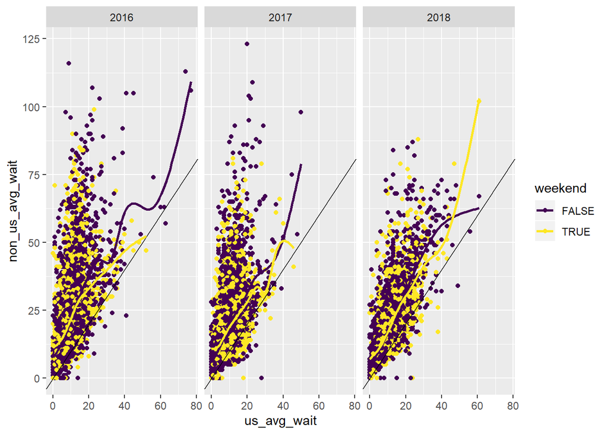

```r
ord %>%
  mutate(weekend=(wday=="Sat")|(wday=="Sun")) %>%
  ggplot(aes(x=us_avg_wait, y=non_us_avg_wait,color=weekend))+
  geom_point()+
  geom_abline()+
  geom_smooth(se=FALSE)+
  facet_wrap(~year)
```

### 5

> Add a column named `booth_rate` to the data set which estimates the average number of passengers per booth per hour. For example, if 1000 passengers arrive between 05:00 and 06:00, the average wait time is 40 minutes, and there are 10 booths open, then an estimate of the total number of passengers per booth per hour could be computed like this: 1000/10 = 100 passengers per booth / (40 minutes per passenger * 1 hour per 60 minutes) = (1000 * 60) / (10 * 40) = 150 passengers per booth per hour. This is an estimate because it assumes available booths change on the hour and it ignores how rates change when passengers wait durations stretch into the next time period.

> After calculating this statistic, make a plot that shows its relationship with day of the week and the hour. Comment on any patterns you see.

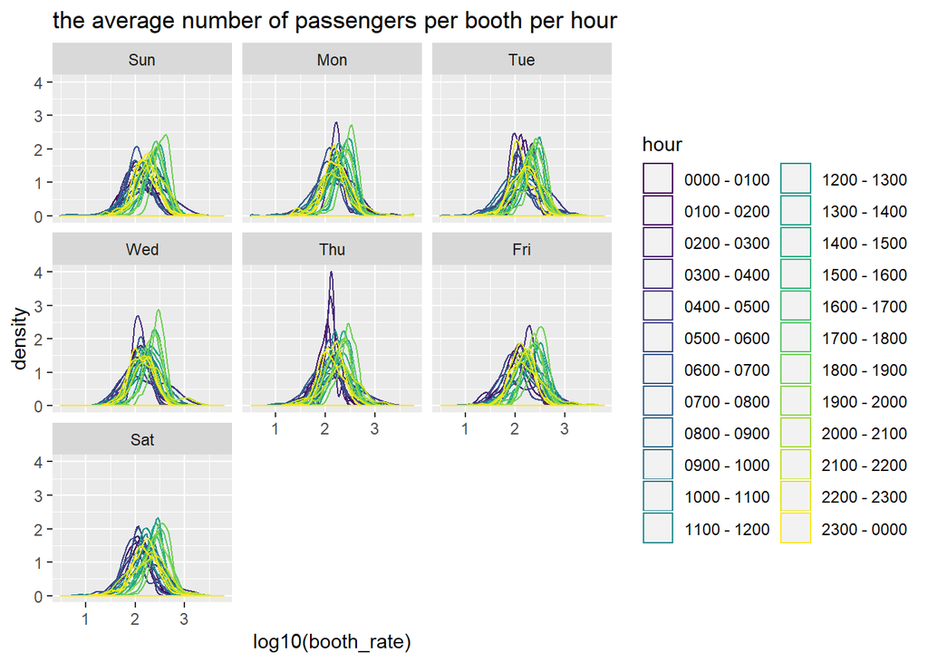

```r
ord %>%
  select(hour,all_avg_wait,passengers,all_booths,wday) %>%
  mutate(booth_rate=((passengers/all_booths)*(60/all_avg_wait)))%>%
  ggplot(aes(x=log10(booth_rate),color=hour))+
  geom_density()+
  facet_wrap(~wday)+
  ggtitle("the average number of passengers per booth per hour")
```

#response

somewhat pattern: –all week days are normally distrbutied.